# Re-timing the drifting analog picks of catalog v4.1 (D-B072)

Written by `scripts/w01_report.py` from `tables/` and `corrections.csv.gz`. Output directory `/wd1/mdenolle_data/tomo_v1/checks/pick_retiming`.

## 1. Verification on our pnwstore archive

For each station-day the day is read as the picker read it (pnwstore tsindex byte ranges → obspy.read → trim to the UTC day → HH>BH>EH vertical → resample(100) → merge(fill_value='interpolate')). At 24 hourly probe times (plus ±60 s around every data restart) the merged-trace sample and its 50 neighbours on each side are looked up, in raw counts, in an ObsPy read of only the records within ±20 s; the time of the matched sample in the short read minus its time in the day trace is plotted. `tables/verify_samples.csv`, `tables/verify_days.csv`, `tables/verify_shortread.csv`.

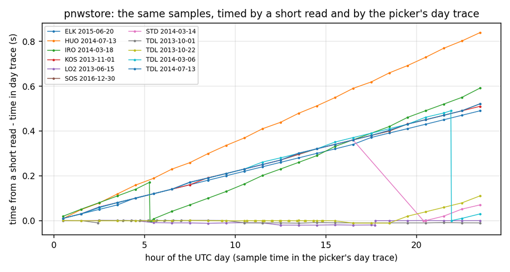

| net | sta | day | why | channel | n_records | n_segments | n_traces_day_read | merged_npts | resample_keeps_grid | max_header_resid_s |
| --- | --- | --- | --- | --- | --- | --- | --- | --- | --- | --- |
| UW | TDL | 2014-07-13 | affected, no gap (EarthScope check day) | EHZ | 13128 | 1 | 1 | 8639947 | True | 0.5315 |
| UW | TDL | 2014-03-06 | affected, gap | EHZ | 12188 | 2 | 2 | 8639996 | True | 0.4914 |
| UW | STD | 2014-03-14 | affected, gap | EHZ | 20050 | 2 | 2 | 8639992 | True | 0.3715 |
| UW | ELK | 2015-06-20 | affected | EHZ | 13179 | 1 | 1 | 8639949 | True | 0.5113 |
| UW | SOS | 2016-12-30 | affected, last catalog days | EHZ | 13043 | 1 | 1 | 8639946 | True | 0.5315 |
| UO | IRO | 2014-03-18 | affected UO, 2 gaps | EHZ | 16067 | 3 | 3 | 8639940 | True | 0.6014 |
| UO | HUO | 2014-07-13 | affected UO | EHZ | 16215 | 1 | 1 | 8639914 | True | 0.86 |
| UW | KOS | 2013-11-01 | affected KOS (to 2013-11-18) | EHZ | 12043 | 1 | 1 | 8639948 | True | 0.5215 |
| UW | TDL | 2013-10-22 | onset day (14:48:30) | EHZ | 14672 | 12 | 12 | 8639988 | True | 0.1205 |
| UW | TDL | 2013-10-01 | before onset | EHZ | 11992 | 11 | 11 | 8640001 | True | 0.0011 |
| UW | LO2 | 2013-06-15 | before onset | EHZ | 12835 | 2 | 2 | 8640000 | True | 0.0048 |
| CC | STD | 2014-07-13 | co-located broadband/digital (CC.STD) | BHZ | 17662 | 1 | 1 | 4320000 | False | 0 |

Notes: a gap-free UW day has 8,639,947 samples instead of 8,640,000 (99.99939 Hz); ObsPy joins every record into one trace (n_traces = n_segments from the header parse, every day). resample(100) keeps the start time and the number of samples of these 100 Hz channels (it does not move samples). CC.STD BHZ is 50 Hz, so the raw-count probe does not apply there (no drift in its headers: max 0.0 s).

## 2. Record-header scan of the station-channels with picks

Every MiniSEED record header of the vertical HH/BH/EH channels of each scanned station-day is parsed (start time as libmseed computes it, checked against ObsPy's `get_record_information`: identical); records are joined as libmseed joins them (|gap| ≤ half a sample) and the header time is compared with the segment start + samples/nominal rate. Coverage, by priority tier: UW, UO, CC: the first pick day of each station in each ISO week plus every day near 2013-10-22, 2013-11-18 and 2014-12 to 2015-02 (plus all days 2010-01-01 to 2010-04-13 from a first pass); other networks: the first pick day of each station in each month; further days as far as the run went. Scanned: 37,671 station-days of 306,684.

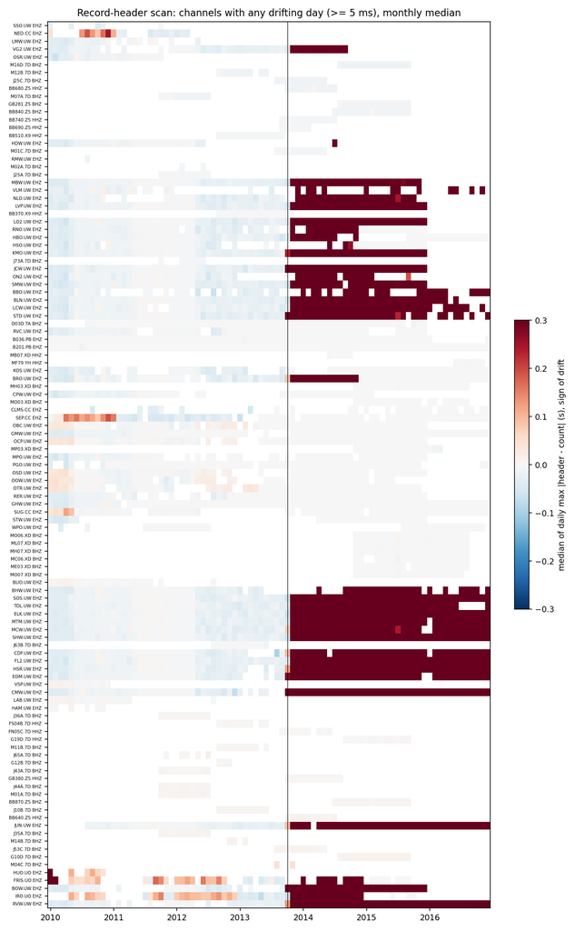

| station | channel | rate | n_days | n_drift | frac_drift | first_drift | last_drift | slope_med_drift | absmax_med_drift | absmax_max | listed |
| --- | --- | --- | --- | --- | --- | --- | --- | --- | --- | --- | --- |
| B036.PB | EHZ | 100 | 74 | 1 | 0.01351 | 2013-02-05 | 2013-02-05 | 0.01485 | 0.01 | 0.01 | False |
| B201.PB | EHZ | 100 | 84 | 1 | 0.0119 | 2010-07-01 | 2010-07-01 | -0.01614 | 0.0102 | 0.0102 | False |
| BB370.X9 | HHZ | 100 | 14 | 1 | 0.07143 | 2013-10-01 | 2013-10-01 | -0.001431 | 0.006133 | 0.006133 | False |
| BB510.X9 | HHZ | 100 | 13 | 13 | 1 | 2012-09-30 | 2013-09-01 | -0.006383 | 0.0064 | 0.006402 | False |
| BB640.Z5 | HHZ | 100 | 10 | 9 | 0.9 | 2013-10-06 | 2014-07-01 | 0.009394 | 0.009393 | 0.009394 | False |
| BB680.Z5 | HHZ | 100 | 10 | 9 | 0.9 | 2013-10-04 | 2014-07-01 | -0.009536 | 0.009535 | 0.009535 | False |
| BB690.Z5 | HHZ | 100 | 6 | 4 | 0.6667 | 2013-09-25 | 2014-02-01 | -0.006808 | 0.006808 | 0.006808 | False |
| BB740.Z5 | HHZ | 100 | 11 | 11 | 1 | 2013-09-28 | 2014-07-01 | -0.006886 | 0.006886 | 0.006886 | False |
| BB840.Z5 | BHZ | 50 | 15 | 14 | 0.9333 | 2014-07-29 | 2015-09-01 | -0.007236 | 0.007236 | 0.007237 | False |
| BB870.Z5 | BHZ | 50 | 15 | 14 | 0.9333 | 2014-07-27 | 2015-09-01 | 0.008686 | 0.008683 | 0.008684 | False |
| BUO.UW | EHZ | 100 | 108 | 32 | 0.2963 | 2010-01-04 | 2011-06-13 | 0.01377 | 0.0119 | 0.0304 | False |
| CLMS.CC | EHZ | 100 | 36 | 10 | 0.2778 | 2010-09-22 | 2013-03-24 | -0.04019 | 0.0303 | 0.0531 | False |
| CPW.UW | EHZ | 100 | 243 | 83 | 0.3416 | 2010-01-05 | 2011-05-23 | -0.04234 | 0.0215 | 0.0951 | False |
| D03D.TA | BHZ | 40 | 64 | 1 | 0.01562 | 2015-10-14 | 2015-10-14 | -0.0002309 | 0.008249 | 0.008249 | False |
| FN05C.7D | HHZ | 125 | 9 | 1 | 0.1111 | 2014-04-23 | 2014-04-23 | 0.007521 | 0.005703 | 0.005703 | False |
| FS04B.7D | HHZ | 125 | 9 | 1 | 0.1111 | 2013-01-01 | 2013-01-01 | 0.007988 | 0.006172 | 0.006172 | False |
| G10D.7D | BHZ | 50 | 14 | 14 | 1 | 2014-08-11 | 2015-09-01 | 0.01113 | 0.01113 | 0.01113 | False |
| G12B.7D | BHZ | 50 | 3 | 3 | 1 | 2012-09-04 | 2012-11-01 | 0.006857 | 0.006856 | 0.006857 | False |
| G19D.7D | HHZ | 125 | 13 | 2 | 0.1538 | 2014-12-01 | 2015-05-01 | 0.006506 | 0.005069 | 0.005073 | False |
| GB281.Z5 | BHZ | 50 | 14 | 14 | 1 | 2014-08-11 | 2015-09-01 | -0.008002 | 0.008001 | 0.008002 | False |
| GB380.Z5 | HHZ | 100 | 11 | 11 | 1 | 2013-10-19 | 2014-08-01 | 0.006951 | 0.00695 | 0.00695 | False |
| GHW.UW | EHZ | 100 | 404 | 70 | 0.1733 | 2010-01-04 | 2011-02-02 | -0.04698 | 0.02295 | 0.0709 | False |
| GMW.UW | EHZ | 100 | 393 | 76 | 0.1934 | 2010-01-02 | 2011-05-23 | -0.02908 | 0.0195 | 0.1018 | False |
| HAM.UW | EHZ | 100 | 8 | 2 | 0.25 | 2010-05-06 | 2010-11-21 | 0.02295 | 0.00775 | 0.0105 | False |
| J10B.7D | BHZ | 50 | 10 | 10 | 1 | 2012-09-05 | 2013-06-02 | 0.008724 | 0.008722 | 0.008723 | False |
| J25A.7D | BHZ | 50 | 10 | 10 | 1 | 2011-10-25 | 2012-07-03 | -0.00257 | 0.0066 | 0.0066 | False |
| J25C.7D | BHZ | 50 | 10 | 10 | 1 | 2013-08-23 | 2014-05-01 | -0.01114 | 0.01114 | 0.01114 | False |
| J35A.7D | BHZ | 50 | 10 | 10 | 1 | 2011-10-21 | 2012-07-02 | 0.009779 | 0.00895 | 0.0096 | False |
| J36A.7D | BHZ | 50 | 10 | 4 | 0.4 | 2011-10-21 | 2012-07-02 | 0.006772 | 0.00605 | 0.0066 | False |
| J43A.7D | BHZ | 50 | 10 | 9 | 0.9 | 2011-10-21 | 2012-07-03 | 0.006907 | 0.006847 | 0.0079 | False |

[output cut: 83 more lines]

`tables/scan_stations.csv` (all channels), `tables/scan_station_month.csv`, `tables/scan_all.csv.gz` (every channel-day).

## 3. Re-timing, pick by pick

1. Rebuild the picker's merged vertical day trace layout (same reads, trim and channel rule; ObsPy merge run on index traces, so each merged sample is known as sample *q* of read trace *k*, and fills are known).
2. The catalog time must fall on that trace's sample grid (|fraction| < 0.001 sample): index *i*.
3. Sample *q* → MiniSEED record *r*, position *p* (cumulative npts from the record that starts the ObsPy trace).
4. Short read: ObsPy reads records *r*−3…*r*+3 only; the 101 raw counts around the sample must be identical at that position (and the uniqueness of the match is recorded).
5. True time = start time of record *r* read alone by ObsPy + *p*/100 (within a ~7 s record the 99.9994 vs 100 Hz count error is < 0.05 ms). Correction = true − catalog.

No rate model is used. Picks inside a merge fill (gaps, overlaps) are timed from the nearest real sample (flag `in_fill`). A station-day is corrected when its channel drifts by ≥ 5 ms (scan) or any of its re-timed picks moves by ≥ 5 ms; all picks of such a day are then set to their sample's header time.

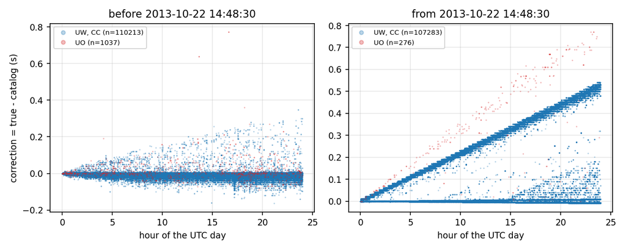

Exact re-timing versus the rate model of the UW check (0.521 s/day UW, 0.79 s/day UO from 00:00 UTC, `a02_model_compare.py`), listed stations inside the model epochs, n=84,400: median |difference| 5.0 ms; |difference| > 0.05 s for 3.7 % and > 0.1 s for 3.4 % of the picks (days where a data restart reset the count, and the UO seasonal rate); 12.4 % of the picks are on days with more than one segment.

| flag | picks |
| --- | --- |
| error | 7 |
| in_fill | 1969 |
| off_grid | 23331 |
| ok | 274630 |
| ok_nonunique | 43 |
| rate_not_100 | 22541 |

| station | epoch_class | n | first | last | median | min | max |
| --- | --- | --- | --- | --- | --- | --- | --- |
| B036.PB | found | 1 | 2013-02-05 | 2013-02-05 | 0.0099 | 0.0099 | 0.0099 |
| B201.PB | found | 13 | 2010-07-01 | 2010-07-02 | -0.0024 | -0.0146 | 0 |
| BB370.X9 | found | 19 | 2013-10-01 | 2013-10-01 | -0.0008 | -0.001101 | -0.000203 |
| BB510.X9 | found | 12442 | 2012-09-30 | 2013-09-24 | -0.0033 | -0.006402 | 2e-06 |
| BB640.Z5 | found | 3637 | 2013-10-06 | 2014-07-29 | 0.004875 | -0.00273 | 0.009389 |
| BB680.Z5 | found | 5207 | 2013-10-04 | 2014-07-27 | -0.004718 | -0.009521 | 0.002675 |
| BB690.Z5 | found | 4781 | 2013-09-25 | 2014-02-21 | -0.003358 | -0.006804 | 0.003291 |
| BB740.Z5 | found | 9236 | 2013-09-28 | 2014-07-26 | -0.003475 | -0.006883 | 0.00324 |
| BBO.UW | found | 135 | 2010-01-08 | 2013-08-25 | -0.0009 | -0.0988 | 0.0045 |
| BBO.UW | listed | 144 | 2014-01-15 | 2016-12-25 | 0.2405 | 2e-06 | 0.51 |
| BHW.UW | found | 721 | 2010-01-01 | 2013-05-09 | -0.0006 | -0.0828 | 0.0052 |
| BHW.UW | listed | 368 | 2014-04-16 | 2016-12-13 | 0.2203 | -0.000611 | 0.5312 |
| BLN.UW | found | 5653 | 2010-01-01 | 2013-10-22 | -0.001 | -0.1095 | 0.0087 |
| BLN.UW | listed | 2866 | 2013-10-22 | 2016-06-24 | 0.2278 | -0.001255 | 0.5311 |
| BOW.UW | found | 685 | 2010-01-02 | 2013-10-21 | -0.0013 | -0.0997 | 0.0107 |
| BOW.UW | listed | 788 | 2013-10-22 | 2015-12-30 | 0.26 | -0.001284 | 0.5312 |
| BRO.UW | found | 335 | 2010-01-02 | 2013-10-11 | -0.0046 | -0.076 | 0.0049 |
| BRO.UW | listed | 245 | 2013-10-22 | 2014-11-20 | 0.26 | -0.001082 | 0.5304 |
| BUO.UW | found | 99 | 2010-01-04 | 2011-06-13 | 0 | -0.0014 | 0.03 |
| CDF.UW | found | 2775 | 2010-01-02 | 2013-10-22 | -0.0005 | -0.1115 | 0.0113 |
| CDF.UW | listed | 3912 | 2013-10-22 | 2016-12-23 | 0.24 | -0.001431 | 0.5404 |
| CLMS.CC | found | 31 | 2010-09-22 | 2013-03-24 | -0.01 | -0.0301 | 0.0013 |
| CMW.UW | found | 1337 | 2010-01-01 | 2013-06-19 | -0.0004 | -0.0927 | 0.0062 |
| CMW.UW | listed | 2081 | 2013-10-23 | 2016-12-30 | 0.24 | -0.001237 | 0.54 |
| CPW.UW | found | 291 | 2010-01-05 | 2011-07-13 | -0.0007 | -0.0643 | 0.0052 |
| EDM.UW | found | 3349 | 2010-01-11 | 2013-10-22 | -0.0006 | -0.09 | 0.0136 |
| EDM.UW | listed | 4837 | 2013-10-22 | 2016-12-23 | 0.2507 | -0.002981 | 0.5405 |
| ELK.UW | found | 4589 | 2010-01-01 | 2013-10-22 | -0.0007 | -0.1384 | 0.0067 |
| ELK.UW | listed | 9862 | 2013-10-22 | 2016-12-31 | 0.2487 | -0.001418 | 0.5412 |
| FL2.UW | found | 6413 | 2010-01-01 | 2013-10-22 | -0.0009 | -0.0959 | 0.0097 |

[output cut: 81 more lines]

## 4. Picks that could not be re-timed (kept unchanged, flagged)

| flag | why | picks |
| --- | --- | --- |
| error | Exception: Can not merge traces with same ids (7D.J43A..BHZ) but differing sampling rates (50.00000762939453, 50.0)! | 7 |
| off_grid | grid fraction 0.0000 | 22730 |
| off_grid | grid fraction 0.0075 | 1 |
| off_grid | grid fraction 0.0099 | 1 |
| off_grid | grid fraction 0.0100 | 11 |
| off_grid | grid fraction 0.0112 | 1 |
| off_grid | grid fraction 0.0117 | 1 |
| off_grid | grid fraction 0.0134 | 1 |
| off_grid | grid fraction 0.0152 | 1 |
| off_grid | grid fraction 0.0153 | 1 |
| off_grid | grid fraction 0.0157 | 1 |
| off_grid | grid fraction 0.0158 | 1 |
| off_grid | grid fraction 0.0171 | 1 |
| off_grid | grid fraction 0.0179 | 1 |
| off_grid | grid fraction 0.0201 | 1 |
| off_grid | grid fraction 0.0204 | 1 |
| off_grid | grid fraction 0.0211 | 1 |
| off_grid | grid fraction 0.0219 | 1 |
| off_grid | grid fraction 0.0234 | 1 |
| off_grid | grid fraction 0.0235 | 1 |
| off_grid | grid fraction 0.0251 | 1 |
| off_grid | grid fraction 0.0255 | 1 |
| off_grid | grid fraction 0.0265 | 1 |
| off_grid | grid fraction 0.0268 | 1 |
| off_grid | grid fraction 0.0284 | 1 |
| off_grid | grid fraction 0.0297 | 1 |
| off_grid | grid fraction 0.0310 | 1 |
| off_grid | grid fraction 0.0312 | 1 |
| off_grid | grid fraction 0.0315 | 1 |
| off_grid | grid fraction 0.0320 | 1 |

[output cut: 170 more lines]

1969 picks fall on merge-filled samples (interpolated across a data restart in the picker's trace); they are timed from the nearest real sample and flagged `in_fill` in corrections.csv. Most sit at network-wide data restarts (e.g. 2013-11-17 14:37:09), so they are probably picks of the restart itself.

## 5. Validation

### (a) Waveform sample of the UW timing check

`uw_timing/tables/wave_measurements_all.csv`: catalog P pick − AIC onset on EarthScope data (filtered as the picker does). After re-timing: the same + correction. `v02_validate.py` → `tables/validation_aic.csv`.

| check | epoch | re_timed | n | n_same_pick | median_before | mad_before | median_after | mad_after | frac_abs_gt_0p1_after | median_correction |
| --- | --- | --- | --- | --- | --- | --- | --- | --- | --- | --- |
| catalog P pick - EarthScope AIC onset | before onset | False | 212 | 139 | -0.02 | 0.03 | -0.02 | 0.03 | 0.08491 | 0 |
| catalog P pick - EarthScope AIC onset | before onset | True | 469 | 469 | -0.009 | 0.029 | -0.0198 | 0.0298 | 0.06183 | -0.0092 |
| catalog P pick - EarthScope AIC onset | after onset | False | 219 | 138 | -0.02 | 0.03 | -0.02 | 0.03 | 0.08676 | 0 |
| catalog P pick - EarthScope AIC onset | after onset | True | 673 | 673 | -0.264 | 0.104 | -0.009999 | 0.02042 | 0.05349 | 0.2498 |

| hour | n | before | after |
| --- | --- | --- | --- |
| 0 | 61 | -0.049 | -0.01 |
| 3 | 68 | -0.101 | -0.004952 |
| 6 | 79 | -0.18 | -0.01001 |
| 9 | 131 | -0.241 | -0.009988 |
| 12 | 130 | -0.305 | -0.01 |
| 15 | 84 | -0.3605 | -0.01004 |
| 18 | 45 | -0.43 | -0.01 |
| 21 | 75 | -0.5 | -0.01002 |

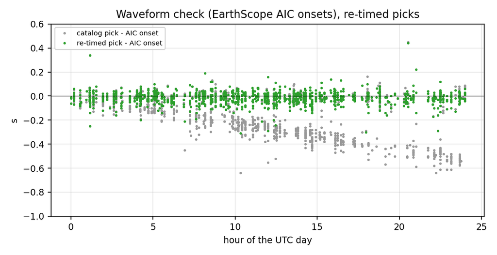

### (b) Co-located pairs

Pick difference SP − reference for the same event and phase (`uw_timing/tables/colocated_pairs.csv`, run b4) → `tables/validation_colocated.csv`.

| pair | phase | epoch | n | n_sp_corrected | median_dpick_before | mad_before | median_dpick_after | mad_after |
| --- | --- | --- | --- | --- | --- | --- | --- | --- |
| CDF.UW-MK08.XD | P | after onset | 1195 | 1195 | -0.1999 | 0.1433 | 0.05274 | 0.05867 |
| CDF.UW-MK08.XD | S | after onset | 1175 | 1174 | -0.1894 | 0.1406 | 0.05131 | 0.08631 |
| ELK.UW-MF68.YH | P | after onset | 563 | 563 | -0.18 | 0.14 | 0.06002 | 0.0689 |
| ELK.UW-MF68.YH | S | after onset | 614 | 613 | -0.1499 | 0.1451 | 0.09 | 0.07943 |
| ELK.UW-MG05.XD | P | after onset | 2890 | 2889 | -0.2039 | 0.1406 | 0.055 | 0.04933 |
| ELK.UW-MG05.XD | S | after onset | 3106 | 3104 | -0.165 | 0.1301 | 0.06597 | 0.05098 |
| KOS.UW-ME06.XD | P | after onset | 892 | 0 | 0.045 | 0.05 | 0.045 | 0.05 |
| KOS.UW-ME06.XD | S | after onset | 646 | 0 | 0.01 | 0.0875 | 0.01 | 0.0875 |
| LO2.UW-LON.UW | P | before onset | 686 | 620 | 0.05515 | 0.03895 | 0.04935 | 0.03865 |
| LO2.UW-LON.UW | S | before onset | 539 | 495 | 0.037 | 0.0565 | 0.032 | 0.0563 |
| NED.CC-SEP.CC | P | before onset | 541 | 495 | -0.01 | 0.09 | -0.01 | 0.08 |
| NED.CC-SEP.CC | S | before onset | 501 | 449 | -0.0601 | 0.2201 | -0.06 | 0.22 |
| SOS.UW-B202.PB | P | before onset | 1194 | 917 | 0.173 | 0.0586 | 0.1718 | 0.0589 |
| SOS.UW-B202.PB | P | after onset | 1140 | 1140 | -0.0384 | 0.1434 | 0.1917 | 0.07005 |
| SOS.UW-B202.PB | S | before onset | 1361 | 998 | 0.393 | 0.1014 | 0.3918 | 0.1011 |
| SOS.UW-B202.PB | S | after onset | 1260 | 1259 | 0.1517 | 0.15 | 0.3916 | 0.111 |
| STD.UW-STD.CC | P | before onset | 1730 | 1230 | 0.08035 | 0.05035 | 0.0799 | 0.0501 |
| STD.UW-STD.CC | P | after onset | 262 | 261 | -0.119 | 0.1148 | 0.1101 | 0.04999 |
| STD.UW-STD.CC | S | before onset | 974 | 655 | 0.0711 | 0.1009 | 0.0701 | 0.1001 |
| STD.UW-STD.CC | S | after onset | 172 | 172 | -0.11 | 0.1205 | 0.09544 | 0.08544 |
| TDL.UW-MF21.YH | P | after onset | 89 | 89 | -0.1149 | 0.1999 | 0.115 | 0.12 |
| TDL.UW-MF21.YH | S | after onset | 69 | 69 | -0.0749 | 0.2499 | 0.08503 | 0.2598 |
| TDL.UW-MG06.XD | P | after onset | 2400 | 2398 | -0.1501 | 0.1401 | 0.06554 | 0.0505 |
| TDL.UW-MG06.XD | S | after onset | 1926 | 1922 | -0.215 | 0.16 | 0.004987 | 0.115 |

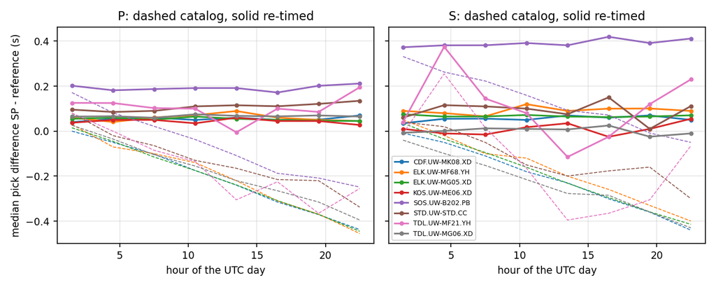

**Which time base is right?** The AIC onsets are themselves timed by EarthScope record headers, so (a) only shows that the re-timed picks agree with the headers. The co-located pairs with a GPS-timed digital reference (LON BHZ, STD.CC BHZ, B202 borehole, MG05/MG06/MK08 OBS) decide it: regressing the pick difference on the correction of the analog pick (least absolute deviations, one intercept per pair and phase, bootstrap SE), the catalog difference has slope −1 and the re-timed one slope 0 if the record headers are right (0 and +1 if the sample count were right), separately for the listed and found classes. `tables/validation_colocated_slope.csv`:

| pair | phase | epoch_class | n | corr_std | slope_catalog | se_catalog | slope_retimed | se_retimed |
| --- | --- | --- | --- | --- | --- | --- | --- | --- |
| CDF.UW-MK08.XD | P | listed | 1195 | 0.1543 | -0.9804 | 0.02087 | 0.01959 | 0.02196 |
| CDF.UW-MK08.XD | S | listed | 1175 | 0.1484 | -0.9464 | 0.02315 | 0.05363 | 0.02296 |
| ELK.UW-MF68.YH | P | listed | 563 | 0.1545 | -1.002 | 0.04006 | -0.002411 | 0.03943 |
| ELK.UW-MF68.YH | S | listed | 614 | 0.1523 | -0.9561 | 0.03862 | 0.04385 | 0.03733 |
| ELK.UW-MG05.XD | P | listed | 2890 | 0.1521 | -1.014 | 0.0113 | -0.01444 | 0.01123 |
| ELK.UW-MG05.XD | S | listed | 3106 | 0.1494 | -0.998 | 0.007713 | 0.001983 | 0.006934 |
| LO2.UW-LON.UW | P | found | 643 | 0.01348 | -0.7957 | 0.2261 | 0.2043 | 0.2185 |
| LO2.UW-LON.UW | S | found | 509 | 0.01397 | -0.7673 | 0.4205 | 0.2327 | 0.404 |
| NED.CC-SEP.CC | P | found | 541 | 0.02567 | -0.9743 | 0.2901 | 0.02573 | 0.2487 |
| NED.CC-SEP.CC | S | found | 501 | 0.02632 | -0.7407 | 0.6472 | 0.2593 | 0.6537 |
| SOS.UW-B202.PB | P | found | 983 | 0.01129 | -1.259 | 0.2722 | -0.2591 | 0.278 |
| SOS.UW-B202.PB | P | listed | 1140 | 0.1439 | -0.9987 | 0.02387 | 0.001271 | 0.02294 |
| SOS.UW-B202.PB | S | found | 1074 | 0.01231 | -0.687 | 0.4236 | 0.313 | 0.502 |
| SOS.UW-B202.PB | S | listed | 1260 | 0.1438 | -0.9067 | 0.03664 | 0.09326 | 0.03762 |
| STD.UW-STD.CC | P | found | 1326 | 0.01168 | -1.259 | 0.1825 | -0.2585 | 0.1783 |
| STD.UW-STD.CC | P | listed | 262 | 0.1449 | -0.9006 | 0.04287 | 0.09937 | 0.04433 |
| STD.UW-STD.CC | S | found | 716 | 0.0109 | -1.736 | 0.7599 | -0.7356 | 0.8907 |
| STD.UW-STD.CC | S | listed | 172 | 0.1523 | -0.7654 | 0.1064 | 0.2346 | 0.1061 |
| TDL.UW-MF21.YH | P | listed | 89 | 0.1531 | -1.305 | 0.1536 | -0.3054 | 0.153 |
| TDL.UW-MF21.YH | S | listed | 69 | 0.1393 | -1.715 | 0.6242 | -0.715 | 0.6208 |
| TDL.UW-MG06.XD | P | listed | 2399 | 0.1571 | -0.9779 | 0.01159 | 0.02208 | 0.01224 |
| TDL.UW-MG06.XD | S | listed | 1925 | 0.1527 | -0.9996 | 0.03471 | 0.00037 | 0.03674 |
| ALL pairs (intercept per pair-phase) | P+S | listed | 16859 | 0.1516 | -0.9922 | 0.006758 | 0.007777 | 0.005835 |
| ALL pairs (intercept per pair-phase) | P+S | found | 6293 | 0.01579 | -1 | 0.1071 | -0.0003158 | 0.1136 |

### (c) Unaffected stations unchanged

| item | value |
| --- | --- |
| rows_not_corrected | 2284818 |
| rows_identical | 2284818 |
| rows_not_identical | 0 |
| rows_corrected | 218809 |
| n_stations_changed | 75 |
| stations_changed | B036.PB B201.PB BB370.X9 BB510.X9 BB640.Z5 BB680.Z5 BB690.Z5 BB740.Z5 BBO.UW BHW.UW BLN.UW BOW.UW BRO.UW BUO.UW CDF.UW CLMS.CC CMW.UW CPW.UW EDM.UW ELK.UW FL2.UW FRIS.UO GB380.Z5 GHW.UW GMW.UW HAM.UW … |
| n_control_picks | 5621 |
| n_control_ok | 2247 |
| control_flags | {'ok': 2247, 'rate_not_100': 2112, 'off_grid': 714, 'error': 544, 'in_fill': 4} |
| control_abs_max | 0.008081 |
| control_frac_abs_ge_5ms | 0.008901 |
| control_median | 0 |

## 6. Files and how to use them

- `Cascadia_picks_catalog_v4.1t.csv`: the full v4.1 pick file, same columns and formatting, plus `timing_corrected` (True/False) and `timing_correction_s`. Corrected rows have the new `pick_datetime` and `travel_time(s)` = new pick − origin time of the event file (origins unchanged).
- `corrections.csv` / `.csv.gz`: one row per re-timed pick (pick_row = 0-based data row of the v4.1 file), old/new time, correction, method, flag, record used.
- README.md: method, numbers, use in the v5.1 relocation.

Scripts (in `scripts/`): prt_common.py (pnwstore index/read, MiniSEED header parser), v01_verify.py, s01_header_scan.py, s02_scan_summary.py, r00_tasks.py, r01_retime.py, r02_ext_tasks.py, r03_control_tasks.py, a01_assemble.py, v02_validate.py, f01_figs.py, w01_report.py.